# It’s wrong…but I cannot explain why!

International Conference on Thinking - 24 June 2021

## Overview

> Cillian McHugh - 24/6/21
- What is Moral Dumbfounding?
- Searching for Dumbfounding
- Responding to Critics (Principles)
- Understanding Moral Dumbfounding

## What is Moral Dumbfounding?

## Moral Dilemmas

> Cillian McHugh - 24/6/21
- Heinz
  - Is it wrong to steal a drug to save a loved one?/Is it wrong to demand profit from a life saving drug?
- Trolley
  - Is it wrong to push someone off a bridge to save five?
- Cannibal
  - Is it wrong to eat meat from a dead body?
- Incest
  - Is it wrong for a brother and sister (Julie and Mark) to make love? (using contraception)
- **Have you got a reason for your Judgement?**

## Moral Dumbfounding: A Brief Overview

> Cillian McHugh - 24/6/21
- Moral dumbfounding occurs when people
  - defend a moral judgement
  - even though they cannot provide supporting reasons
- Manifests as:
  - Admissions of not having reasons
  - Use of
    - unsupported declarations (“*it’s just wrong*”) or
    - tautological reasons (“*because it’s incest*”)
- Typically occurs for *harmless taboos*

(Haidt, 2001; Haidt, Björklund, & Murphy, 2000; McHugh, McGann, Igou, & Kinsella, 2017; Royzman, Kim, & Leeman, 2015)

## Dumbfounded by *Incest*

> Cillian McHugh - 24/6/21

[interactive chart not shown]

## Influence of Moral Dumbfounding

> Cillian McHugh - 24/6/21
- Moral Dumbfounding is cited as evidence for
  - *intuitionist* or *dual-process* theories of moral judgement
    - e.g., Crockett (2013); Cushman (2013); Greene (2008); Haidt (2001)
  - over more *rationalist* approaches
    - e.g., Kohlberg (1969); Topolski, Weaver, Martin, & McCoy (2013)
- Its discovery (Haidt, Björklund, & Murphy, 2000) coincided with
  - (and arguably contributed to)
  - the recent rise in *intuitionist* theories of moral judgements (Haidt, 2001)

## Searching for Moral Dumbfounding

## Background

> Cillian McHugh - 24/6/21
- Haidt, Björklund, & Murphy (2000) widely discussed but:
  - *unpublished manuscript* (no peer review)
  - *N* = 30
  - No direct replication
  - Dumbfounding has been contested by some authors

    (e.g., Gray, Schein, & Ward, 2014; Guglielmo, 2018; Jacobson, 2012; Royzman, Kim, & Leeman, 2015; Sneddon, 2007; Wielenberg, 2014)
- We conducted 3 studies:
  - **Study 1**: Interview - replication of Haidt, Björklund, & Murphy (2000)
  - **Study 2**: Computer task 1
  - **Study 3**: Computer task 2 (college sample: 3a; MTurk Sample: 3b)

## Searching: Study 1: Method

> Cillian McHugh - 24/6/21

### Participants:

- 31 participants (MIC/UL students and alumni)

  (15 female, 16 male, 0 other; *M*<sub>age</sub> = 28.83, min = 19, max = 64, *SD* = 10.99)

### Procedure:

- Participants presented with 4 scenarios and asked to judge the behaviour of the characters in the scenarios (*Heinz, Cannibal, Incest, Trolley*)
- The Experimenter challenged the judgement
- Responses of interest:
  - Admissions of not having reasons
  - Unsupported declarations

(McHugh, McGann, Igou, & Kinsella, 2017)

## Searching: Study 1: Results

> Cillian McHugh - 24/6/21

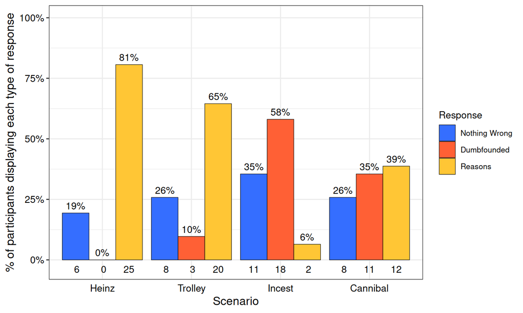

*Rates of each type of response for each scenario*

## Searching: Study 1: Coded Videos

> Cillian McHugh - 24/6/21
- Analysis revealed significant differences in:
  - Laughing
  - Smiling
  - Silence
- No differences in:
  - verbal hesitations; non-verbal hesitations
  - changing posture; fidgeting/hands on the self
  - frowning
- No difference depending on which measure of dumbfounding was used (Admissions of not having reasons / Unsupported declarations)

## Searching: Study 2: Method

> Cillian McHugh - 24/6/21

### Rationale:

- Address limitations of interview (sample size; time/resources)

### Participants:

- 72 participants (MIC/UL students and alumni)

  (52 female, 20 male, 0 other; *M*<sub>age</sub> = 21.18, min = 18, max = 50, *SD* = 5.18)

### Procedure:

- Computer based task: Same scenarios (*Heinz, Cannibal, Incest, Trolley*)
- Series of counter-arguments challenged judgements
- Critical Slide

## Searching: Study 2: Critical Slide

> Cillian McHugh - 24/6/21

“Julie and Mark’s actions did not harm anyone or negatively affect anyone. How can there be anything wrong with what they did?”

1. There is nothing wrong
2. Incest is just wrong
3. It’s wrong and I can provide a valid reason

## Searching: Study 2: Critical Slide

> Cillian McHugh - 24/6/21

[figure not shown]

“Julie and Mark’s actions did not harm anyone or negatively affect anyone. How can there be anything wrong with what they did?”

1. There is nothing wrong
2. Incest is just wrong
3. It’s wrong and I can provide a valid reason

## Searching: Study 2: Results

> Cillian McHugh - 24/6/21

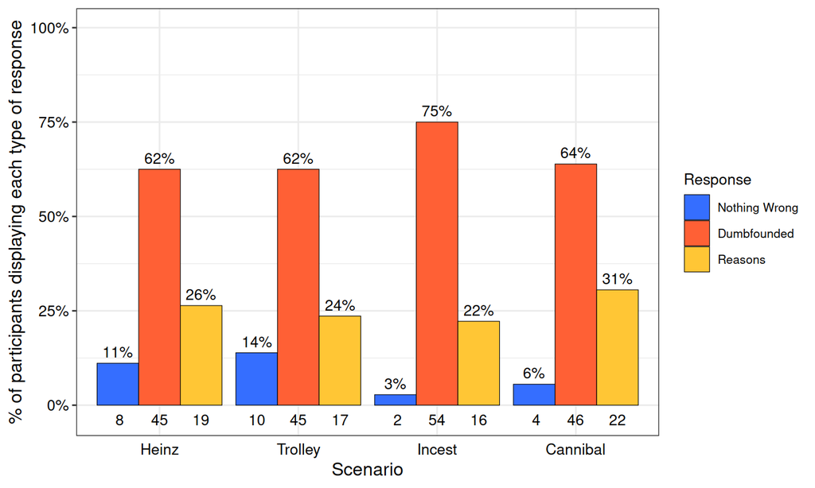

*Rates of each type of response for each scenario*

## Searching: Study 3: Method

> Cillian McHugh - 24/6/21

### Rationale:

- Address Limitations in Study 2

### Participants:

- 173 participants (99 female, 73 male, 1 other; *M*<sub>age</sub> = 30.53, min = 18, max = 69, *SD* = 12.27)
  - MIC/UL students and alumni, *N* = 72 (46 female, 26 male, 0 other; *M*<sub>age</sub> = 21.8, min = 18, max = 46, *SD* = 3.91)
  - MTurk *N* = 101 (53 female, 47 male, 1 other; *M*<sub>age</sub> = 36.58, min = 18, max = 69, *SD* = 12.45)

## Searching: Study 3: Method

> Cillian McHugh - 24/6/21

### Procedure:

- Same as Study 2 with:
  - Change to Critical Slide
    - Explicit admissions replaced Unsupported Declarations
  - ‘Open-ended response’ option after Critical Slide
    - Responses coded for Unsupported Declarations

## Searching: Study 3: Critical Slide

> Cillian McHugh - 24/6/21

“Julie and Mark’s actions did not harm anyone or negatively affect anyone. How can there be anything wrong with what they did?”

1. There is nothing wrong
2. It’s wrong but I can’t think of a reason
3. It’s wrong and I can provide a valid reason

## Searching: Study 3: Critical Slide

> Cillian McHugh - 24/6/21

[figure not shown]

“Julie and Mark’s actions did not harm anyone or negatively affect anyone. How can there be anything wrong with what they did?”

1. There is nothing wrong
2. It’s wrong but I can’t think of a reason
3. It’s wrong and I can provide a valid reason

## Searching: Study 3: Results - Admissions Only

> Cillian McHugh - 24/6/21

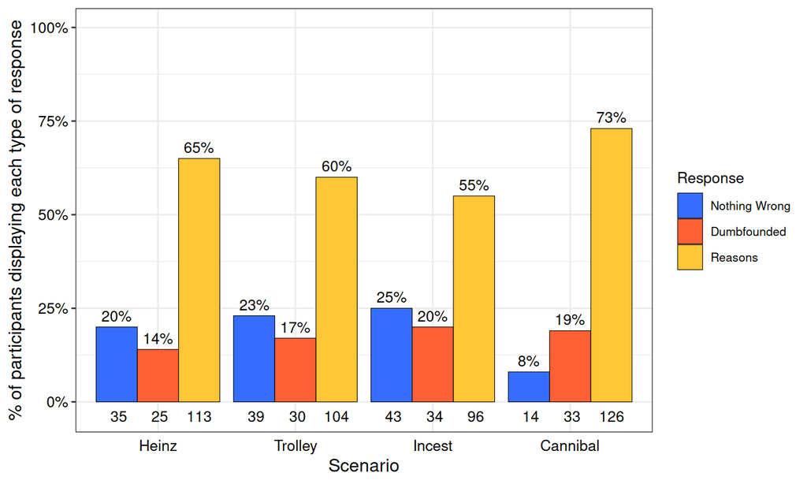

*Rates of each type of response for each scenario*

## Searching: Study 3: Results - *incl. “Declarations”*

> Cillian McHugh - 24/6/21

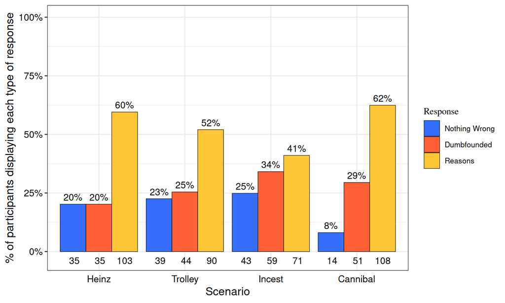

*Rates of each type of response for each scenario*

## Replication in More Diverse Samples

> Cillian McHugh - 24/6/21

### Study 4: Chinese Sample

- 42 (34 female, 8 male, 0 other; *M<sub>age</sub>* = 21.43, min = 18, max = 27, *SD* = 1.74)
- 123 (75 female, 48 male, 0 other; *M*<sub>age</sub> = 22.06, min = 18, max = 45, *SD* = 3.76) participants completed *Cannibal* only

### Study 5: Indian Sample

- 181 (114 female, 64 male, 0 other, 3 missing; *M<sub>age</sub>* = 22.96, min = 18, max = 39, *SD* = 2.42)

## Replication in More Diverse Samples

> Cillian McHugh - 24/6/21

### Study 6: MENA (primarily) Sample

- 253 (154 female, 92 male, 3 other, 4 missing; *M<sub>age</sub>* = 28.05, min = 18, max = 68, *SD* = 12.54).
- *Heinz*, *Trolley*, *Dog*, *Promise*

**Breakdown by Country**:

Algeria (*n* = 2), Bahrain (*n* = 5), Bangladesh (*n* = 2), Egypt (*n* = 25), India (*n* = 21), Iran (*n* = 2), Iraq (*n* = 9), Israel (*n* = 1), Jordan (*n* = 9), Kuwait (*n* = 5), Lebanon (*n* = 31), Libya (*n* = 14), Morocco (*n* = 1), Oman (*n* = 1), Pakistan (*n* = 8), Palestine (*n* = 14), Philippines (*n* = 13), Saudi Arabia (*n* = 1), South Africa (*n* = 1), Sri Lanka (*n* = 3), Sudan (*n* = 33), Syria (*n* = 30), UAE (*n* = 21), Yemen (*n* = 1).

## Study 4: Replication in a Chinese Sample

> Cillian McHugh - 24/6/21

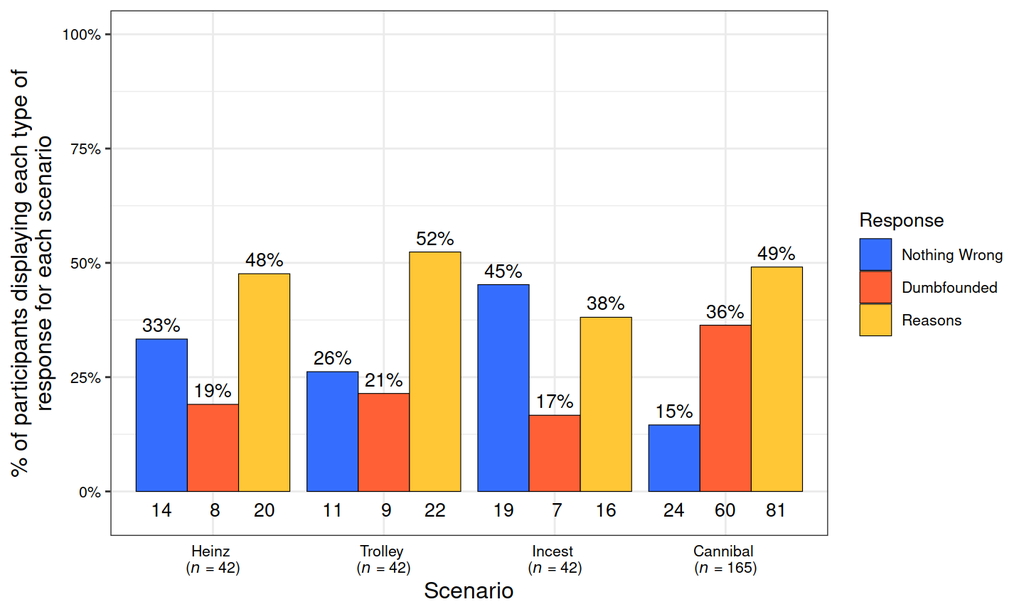

Rates of each type of response for each scenario in the Chinese Sample

## Study 5: Replication in an Indian Sample

> Cillian McHugh - 24/6/21

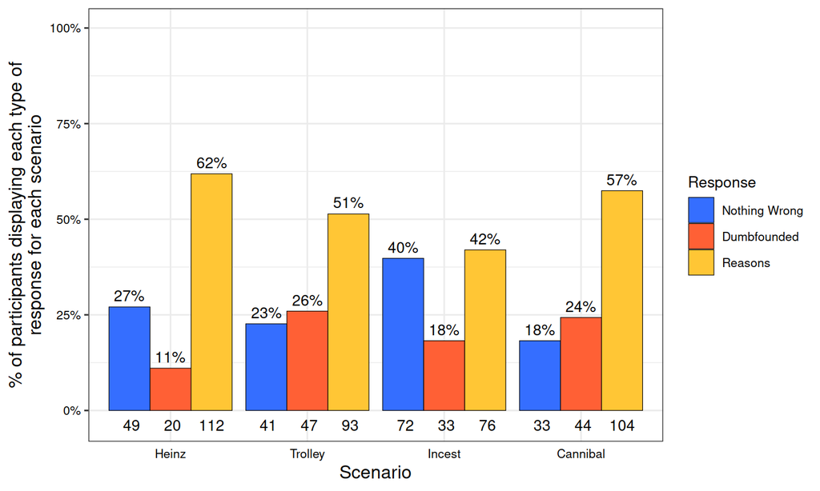

Rates of each type of response for each scenario in the Indian Sample (*N* = 181)

## Study 6: Replication in MENA Sample

> Cillian McHugh - 24/6/21

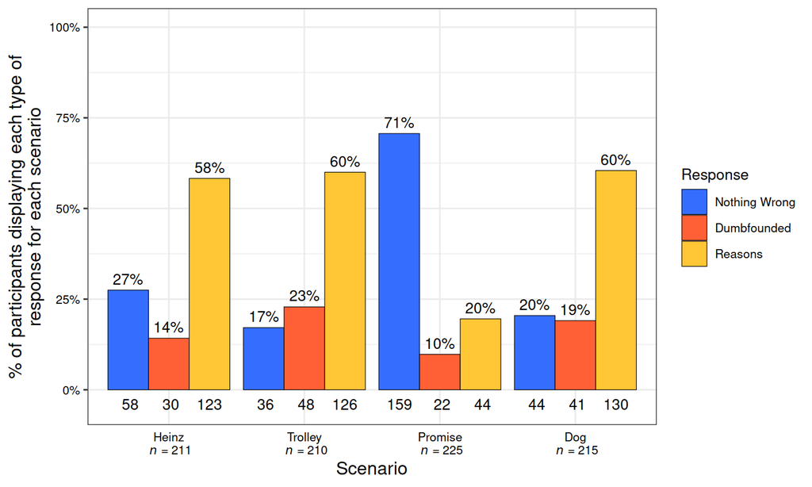

Rates of each type of response for each scenario in the Mixed Sample

## Searching: General Discussion

> Cillian McHugh - 24/6/21
- Dumbfounded responding can be elicited by both Interview and Computerised task
- Can be measured by
  - Admission of not having reasons (too strict?)
  - Unsupported declarations (not strict enough?)
- Difference between Computer task and Interview?

## Responding to Criticisms: The role of Principles

## Criticisms of Moral Dumbfounding

> Cillian McHugh - 24/6/21
- Critics suggest dumbfounding is a non-phenomenon
- Failure to provide reasons does not mean there are no reasons (Sneddon, 2007)
- People implicitly perceive harm (Gray, Schein, & Ward, 2014)
- People have do have reasons but are “beaten into submission” (Jacobson, 2012)
- Evidence for principles or reasons guiding judgements (Royzman, Kim, & Leeman, 2015)

## Evidence for Principles Guiding Judgements

> Cillian McHugh - 24/6/21
- Royzman, Kim, and Leeman (2015) identified two principles that appear to be guiding judgements
- The Harm Principle
- The Norm Principle
- Participants who endorse either principle have a reason to judge the behaviour of *Julie and Mark* as wrong

## Evidence for Principles Guiding Judgements

> Cillian McHugh - 24/6/21
- Exclusion of participants:
  - Harm Based Reasons
  - Norm Based Reasons

## Evidence for Principles Guiding Judgements

> Cillian McHugh - 24/6/21
- Exclusion of participants:
  - **Harm Based Reasons**
  - Norm Based Reasons
- Harm Questions – (yes/no)

## Evidence for Principles Guiding Judgements

> Cillian McHugh - 24/6/21
- Exclusion of participants:
  - **Harm Based Reasons**
  - Norm Based Reasons
- Harm Questions – (yes/no)
  - “are you able to **believe** that Julie and Mark’s having sex with each other **will not negatively affect** the quality of their relationship or how they feel about each other later on?”

## Evidence for Principles Guiding Judgements

> Cillian McHugh - 24/6/21
- Exclusion of participants:
  - **Harm Based Reasons**
  - Norm Based Reasons
- Harm Questions – (yes/no)
  - “are you able to **believe** that Julie and Mark’s having sex with each other **will not negatively affect** the quality of their relationship or how they feel about each other later on?”
  - “are you able to **believe** that Julie and Mark’s having sex with each other **will have no bad consequences** for them personally and/or for those close to them?”

## Evidence for Principles Guiding Judgements

> Cillian McHugh - 24/6/21
- Exclusion of participants:
  - **Harm Based Reasons**
  - Norm Based Reasons
- Harm Questions – (yes/**no**)
  - “are you able to **believe** that Julie and Mark’s having sex with each other **will not negatively affect** the quality of their relationship or how they feel about each other later on?”
  - “are you able to **believe** that Julie and Mark’s having sex with each other **will have no bad consequences** for them personally and/or for those close to them?”

## Evidence for Principles Guiding Judgements

> Cillian McHugh - 24/6/21
- Exclusion of participants:
  - Harm Based Reasons
  - **Norm Based Reasons**
- Norm Statements – (select one)

## Evidence for Principles Guiding Judgements

> Cillian McHugh - 24/6/21
- Exclusion of participants:
  - Harm Based Reasons
  - **Norm Based Reasons**
- Norm Statements – (select one)
  - “violating an established moral norm just for fun or personal enjoyment is wrong **only in situations where someone is harmed as a result**, but is *acceptable otherwise*.”
  - “violating an established moral norm just for fun or personal enjoyment is **inherently wrong** *even in situations where no one is harmed as a result*.”

## Evidence for Principles Guiding Judgements

> Cillian McHugh - 24/6/21
- Exclusion of participants:
  - Harm Based Reasons
  - **Norm Based Reasons**
- Norm Statements – (select one)
  - “violating an established moral norm just for fun or personal enjoyment is wrong **only in situations where someone is harmed as a result**, but is *acceptable otherwise*.”
  - “violating an established moral norm just for fun or personal enjoyment is **inherently wrong** *even in situations where no one is harmed as a result*.”

## Evidence for Principles Guiding Judgements

> Cillian McHugh - 24/6/21

(Royzman, Kim, & Leeman, 2015)

- By excluding participants who endorsed either principle, moral dumbfounding effectively disappeared…

## Response to Royzman et al.

> Cillian McHugh - 24/6/21
- Endorsing is not enough
- Articulating independent of a “prompt”
- Applying across different contexts

## Principles: Overview

> Cillian McHugh - 24/6/21

### 3 Studies

- **Study 7**: Articulating either principle
- **Study 8**: Articulating the Norm principle or Articulating *and* Applying the Harm principle
- **Study 9**: Replication of Study 8

### 3 Exclusion Criteria

- Endorsing (Royzman, Kim, & Leeman, 2015, all studies)
- Articulating (all studies)
- Applying (Studies 8 and 9)

(McHugh, McGann, Igou, & Kinsella, 2020)

## Principles: Participants

> Cillian McHugh - 24/6/21

### Study 9:

- 502 (287 female, 212 male, 3 other; *M*<sub>age</sub> = 39.05, min = 18, max = 81, *SD* = 12.46)

## Principles: Results: Study 7

> Cillian McHugh - 24/6/21

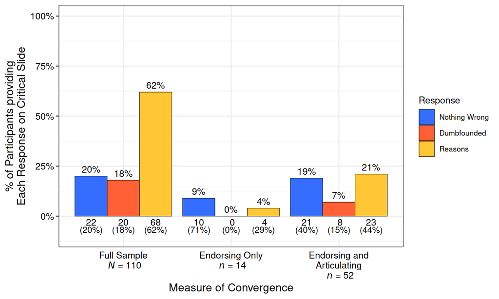

*Responses to critical slide and exclusion*

## Principles: Results: Study 8

> Cillian McHugh - 24/6/21

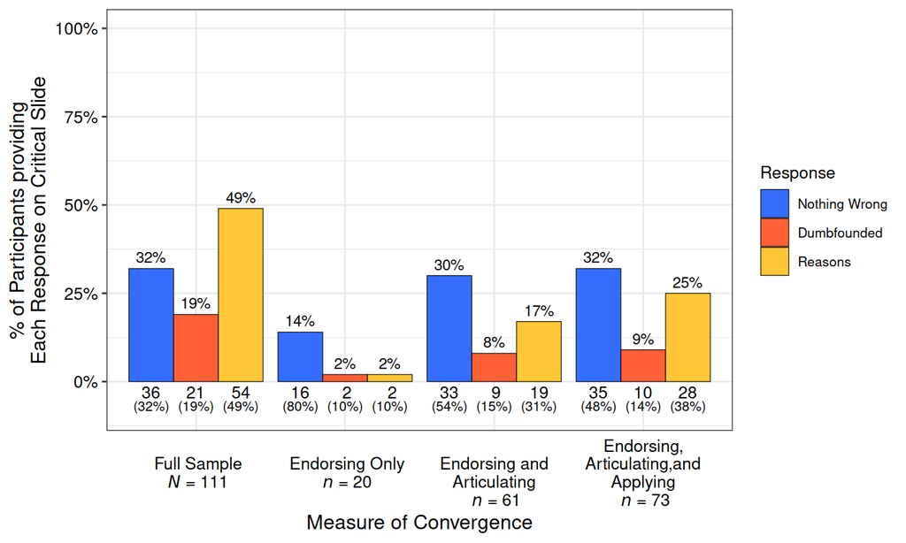

*Responses to critical slide and exclusion*

## Principles: Results: Study 9

> Cillian McHugh - 24/6/21

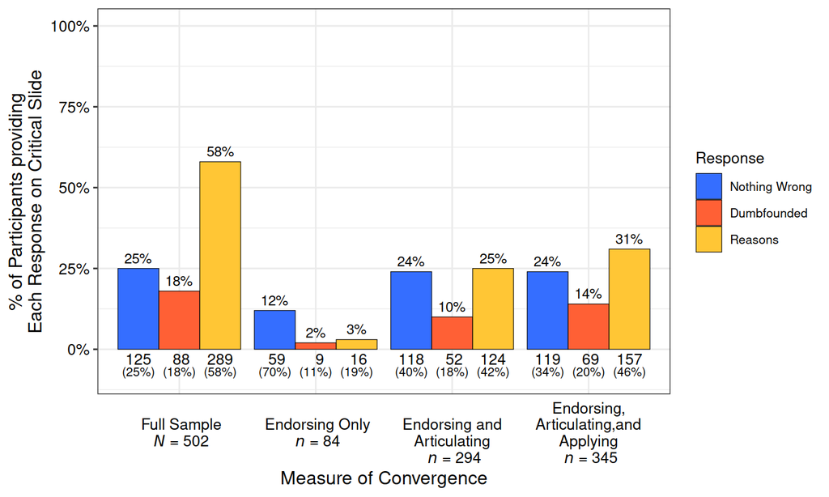

*Responses to critical slide and exclusion*

## Exclusion of Participants

> Cillian McHugh - 24/6/21

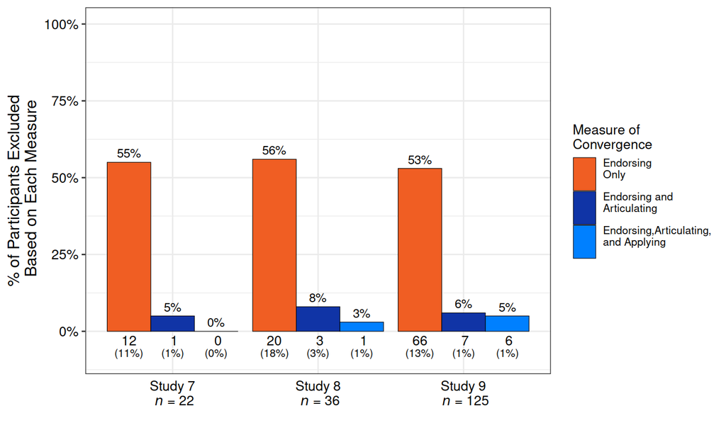

*Responses to critical slide and exclusion*

## Understanding Moral Dumbfounding

## Dual-processes / Dual-systems

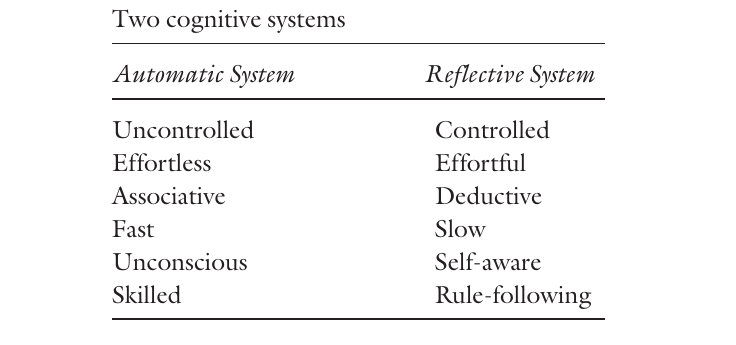

(taken from Thaler & Sunstein, 2008, p. 20)

## Dual-Processes and Moral Dumbfounding

> Cillian McHugh - 24/6/21
- Dual-process theories of moral judgement
- Conflict in dual-process occurs when
  - a habitual (System 1) response is different
  - from a response that results from deliberation (System 2)
- Three response options in the dumbfounding paradigm
  - It’s wrong and I can provide a valid reason
  - It’s wrong but I can’t think of a reason
  - There is nothing wrong (competing intuitions)

(Crockett, 2013; Cushman, 2013; Evans, 2007; Evans & Stanovich, 2013; Greene, 2008)

## Dual-Processes and Moral Dumbfounding

> Cillian McHugh - 24/6/21
- Dual-process theories of moral judgement
- Conflict in dual-process occurs when
  - a habitual (System 1) response is different
  - from a response that results from deliberation (System 2)
- Three response options in the dumbfounding paradigm
  - It’s wrong and I can provide a valid reason
  - It’s wrong but I can’t think of a reason
  - There is nothing wrong (competing intuitions)

(Crockett, 2013; Cushman, 2013; Evans, 2007; Evans & Stanovich, 2013; Greene, 2008)

## Dual-Processes and Moral Dumbfounding

> Cillian McHugh - 24/6/21
- Dual-process theories of moral judgement
- Conflict in dual-process occurs when
  - a habitual (System 1) response is different
  - from a response that results from deliberation (System 2)
- Three response options in the dumbfounding paradigm
  - **It’s wrong and I can provide a valid reason**
  - It’s wrong but I can’t think of a reason
  - There is nothing wrong (competing intuitions)

(Crockett, 2013; Cushman, 2013; Evans, 2007; Evans & Stanovich, 2013; Greene, 2008)

## Dual-Processes and Moral Dumbfounding

> Cillian McHugh - 24/6/21
- Dual-process theories of moral judgement
- Conflict in dual-process occurs when
  - a habitual (System 1) response is different
  - from a response that results from deliberation (System 2)
- Three response options in the dumbfounding paradigm
  - It’s wrong and I can provide a valid reason
  - **It’s wrong but I can’t think of a reason**
  - There is nothing wrong (competing intuitions)

(Crockett, 2013; Cushman, 2013; Evans, 2007; Evans & Stanovich, 2013; Greene, 2008)

## Dual-Processes and Moral Dumbfounding

> Cillian McHugh - 24/6/21
- Dual-process theories of moral judgement
- Conflict in dual-process occurs when
  - a habitual (System 1) response is different
  - from a response that results from deliberation (System 2)
- Three response options in the dumbfounding paradigm
  - It’s wrong and I can provide a valid reason
  - It’s wrong but I can’t think of a reason
  - **There is nothing wrong (competing intuitions)**

(Crockett, 2013; Cushman, 2013; Evans, 2007; Evans & Stanovich, 2013; Greene, 2008)

## Dual-Processes and Moral Dumbfounding

> Cillian McHugh - 24/6/21
- Dual-process theories of moral judgement
- Conflict in dual-process occurs when
  - a habitual (System 1) response is different
  - from a response that results from deliberation (System 2)
- Three response options in the dumbfounding paradigm
  - It’s wrong and I can provide a valid reason
  - It’s wrong but I can’t think of a reason
  - There is nothing wrong (competing intuitions)

(Crockett, 2013; Cushman, 2013; Evans, 2007; Evans & Stanovich, 2013; Greene, 2008)

## Cognitive Load and Moral Dumbfounding

> Cillian McHugh - 24/6/21
- Manipulations of Cognitive load are known to inhibit deliberative responding
- Recall the three response options in dumbfounding
  - (a) It’s wrong and I can provide a valid reason
  - (b) It’s wrong but I can’t think of a reason
  - (c) There is nothing wrong (competing intuitions)

**Cognitive load & dumbfounded responding**

**↓** **↓** **↓** **↓** Giving reasons (a) **↓** **↓** **↓** **↓**

**↑** **↑** Dumbfounded responding (b) **↑** **↑** **↑**

**↑** **↑** There is nothing wrong (c) **↑**

## Individual Differences in Moral Dumbfounding

> Cillian McHugh - 24/6/21
- Dumbfounded responding may be linked with individual differences
- Need for Cognition has been linked to dual-process approaches to cognition
- The Need for Cognition Scale (NFC) is a measure of an individual’s tendency  
  *“to engage in and enjoy effortful analytic activity”*

(Forsterlee & Ho, 1999, p. 471; see also Cacioppo & Petty, 1982)

- tendency to engage in deliberation
- a person’s need to understand and make sense of the world

(Cacioppo & Petty, 1982; Evans & Stanovich, 2013; Forsterlee & Ho, 1999; Petty, Cacioppo, & Kao, 1984; Petty, Feinstein, Blair, & Jarvis, 1996)

## Individual Differences in Moral Dumbfounding

> Cillian McHugh - 24/6/21

### We hypothesised:

- People who score highly on the NFC
  - will be more likely to provide reasons for their judgement
- People who score low on the NFC
  - are likely to fail to identify reasons for their judgement
- NFC is related to a need to understand and make sense of the world
  - Of the people who fail to identify reasons for their judgement:
    - those who revise their judgement will likely score higher on the NFC than people who provide a dumbfounded response

## Cognitive Load Manipulations (Studies 10 & 14)

> Cillian McHugh - 24/6/21

[figure not shown]

## Cognitive Load Manipulations (Studies 11, 12, & 13)

> Cillian McHugh - 24/6/21

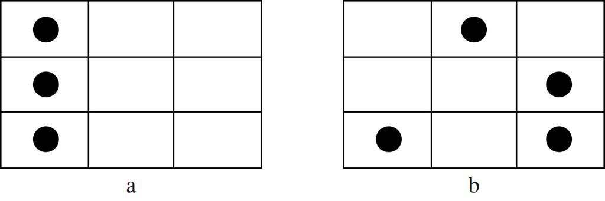

Sample dot patterns

(scored out of 9; 1 misplaced dot = 7/9)

(taken from De Neys & Schaeken, 2007)

## Understanding: Results

> Cillian McHugh - 24/6/21
- **Study 10:** **Significant association** between response to the Critical Slide and Cognitive Load; No significant association with NFC
- **Study 11:** **Significant association** between response to the Critical Slide and Cognitive Load; No significant association with NFC
- **Study 12:** **Significant association** between response to the Critical Slide and Cognitive Load; **Significant association** with NFC
- **Study 13:** No significant association between response to the Critical Slide and Cognitive Load; No significant association with NFC
- **Study 14:** No significant association between response to the Critical Slide and Cognitive Load; No significant association with NFC

## Understanding: Study 10: Results

> Cillian McHugh - 24/6/21

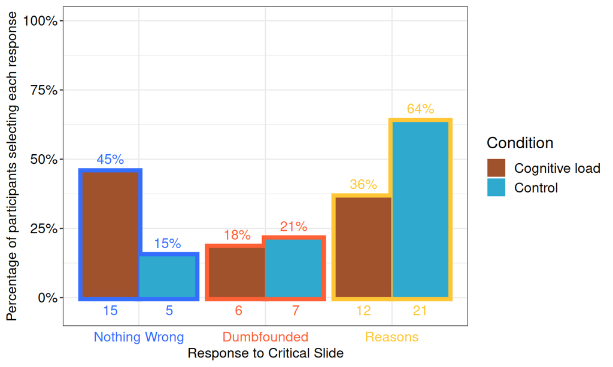

## Understanding: Study 11: Results

> Cillian McHugh - 24/6/21

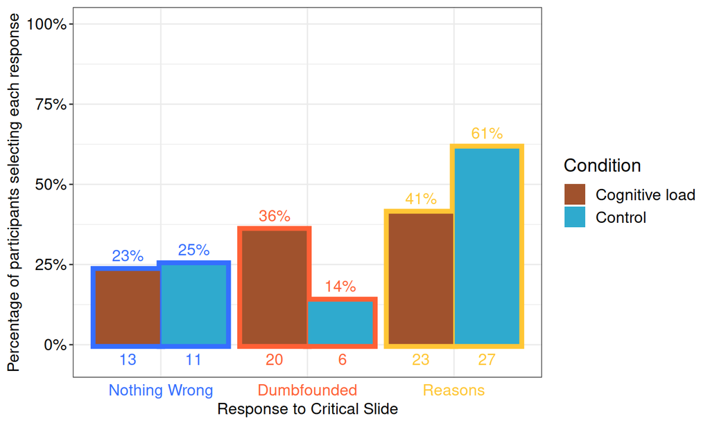

## Understanding: Study 12: Results

> Cillian McHugh - 24/6/21

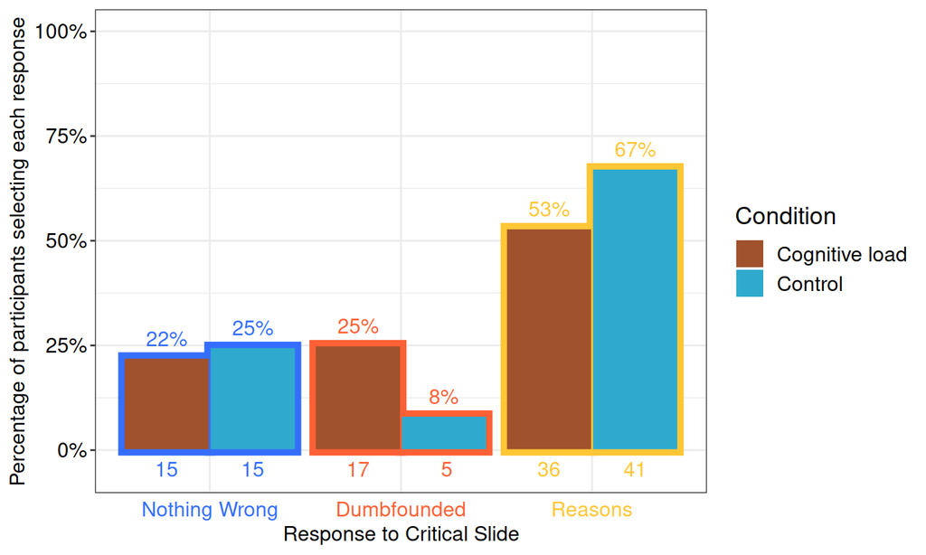

## Understanding: Study 13: Results

> Cillian McHugh - 24/6/21

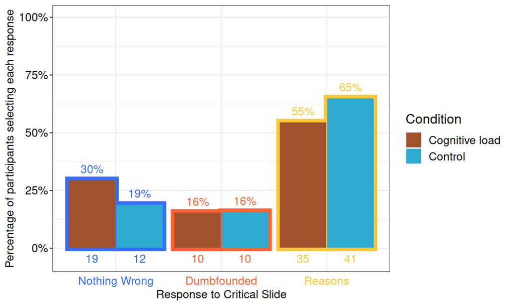

## Understanding: Study 14: Results

> Cillian McHugh - 24/6/21

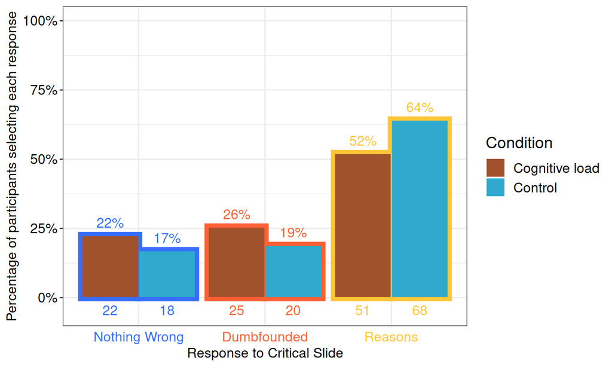

## Cognitive Load and Dumbfounded Responding

> Cillian McHugh - 24/6/21

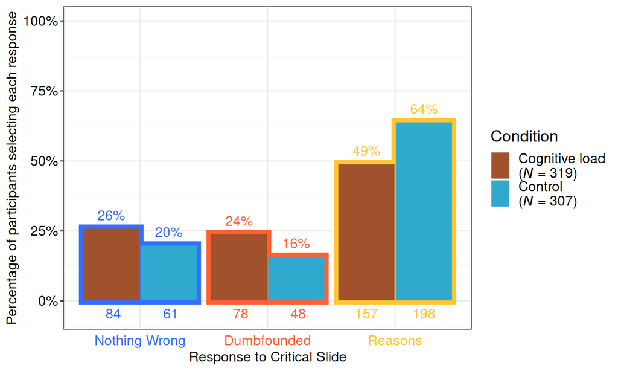

## Cognitive Load and Dumbfounded Responding

> Cillian McHugh - 24/6/21

**Significant association** between response to the Critical Slide and Cognitive Load

|  | Cognitive Load | Control |
| --- | --- | --- |
| Nothing Wrong | 1.92 | -1.92 |
| Dumbfounded | 2.75* | -2.75* |
| Reason | -3.86** | 3.86** |

Note: * = sig. at *p* < .05 ( |z| > 1.96); ** = sig. at *p* < .001 ( |z| > 3.3)

- χ<sup>2</sup>(2, *N* = 626) = 15.302, *p* < .001, *V* = 0.16, the observed power was 0.95

## Cognitive Load and Dumbfounded Responding

> Cillian McHugh - 24/6/21
- A mini meta-analysis found that cognitive load significantly influenced responding across all studies
  - χ<sup>2</sup>(10) = 26.882, *p* = .003 (Fisher’s method)
  - when weighting for sample size, *z* = 2.874, *p* = .002 (Stouffer’s Z-score method)

## Cognitive Load and Dumbfounded Responding

> Cillian McHugh - 24/6/21

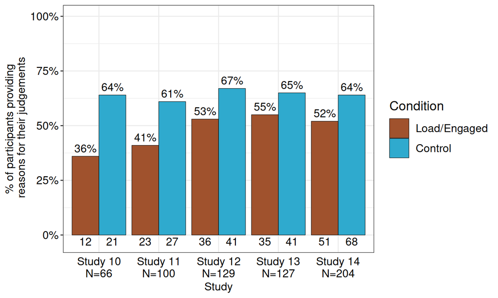

## Need for Cognition

> Cillian McHugh - 24/6/21

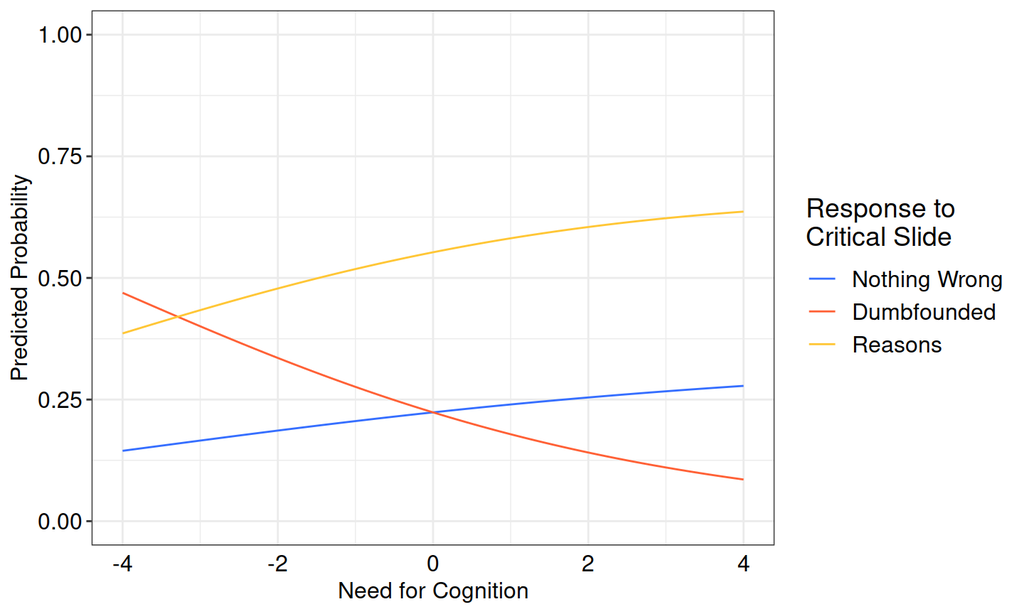

*Probability of each response depending on Need for Cognition*

## Conclusion

## Conclusion

> Cillian McHugh - 24/6/21
- People cannot always provide reasons for their moral judgements
- Dumbfounding occurs for a range of scenarios, and in diverse samples
- Further research is required to understand the mechanisms that lead to moral dumbfounding

## Thank You for Listening!

## References

## References

Cacioppo, J. T., & Petty, R. E. (1982). The need for cognition. *Journal of Personality and Social Psychology*, *42*(1), 116–131. https://doi.org/10.1037/0022-3514.42.1.116

Crockett, M. J. (2013). Models of morality. *Trends in Cognitive Sciences*, *17*(8), 363–366. https://doi.org/10.1016/j.tics.2013.06.005

Cushman, F. A. (2013). Action, Outcome, and Value A Dual- System Framework for Morality. *Personality and Social Psychology Review*, *17*(3), 273–292. https://doi.org/10.1177/1088868313495594

De Neys, W., & Schaeken, W. (2007). When people are more logical under cognitive load: Dual task impact on scalar implicature. *Experimental Psychology*, *54*(2), 128–133. https://doi.org/10.1027/1618-3169.54.2.128

Evans, J. St. B. T. (2007). On the resolution of conflict in dual process theories of reasoning. *Thinking & Reasoning*, *13*(4), 321–339. https://doi.org/10.1080/13546780601008825

Evans, J. St. B. T., & Stanovich, K. E. (2013). Dual- Process Theories of Higher Cognition: Advancing the Debate. *Perspectives on Psychological Science*, *8*(3), 223–241. https://doi.org/10.1177/1745691612460685

Forsterlee, R., & Ho, R. (1999). An Examination of the Short form of the Need for Cognition Scale Applied in an Australian Sample. *Educational and Psychological Measurement*, *59*(3), 471–480. https://doi.org/10.1177/00131649921969983

Gray, K. J., Schein, C., & Ward, A. F. (2014). The myth of harmless wrongs in moral cognition: Automatic dyadic completion from sin to suffering. *Journal of Experimental Psychology: General*, *143*(4), 1600–1615. https://doi.org/10.1037/a0036149

Greene, J. D. (2008). The Secret Joke of Kant’s Soul. In *Moral Psychology Volume 3: The neurosciences of morality: Emotion, brain disorders, and development* (pp. 35–79). Cambridge (Mass.): the MIT press.

Guglielmo, S. (2018). Unfounded dumbfounding: How harm and purity undermine evidence for moral dumbfounding. *Cognition*, *170*, 334–337. https://doi.org/10.1016/j.cognition.2017.08.002

Haidt, J. (2001). The emotional dog and its rational tail: A social intuitionist approach to moral judgment. *Psychological Review*, *108*(4), 814–834. https://doi.org/10.1037/0033-295X.108.4.814

Haidt, J., Björklund, F., & Murphy, S. (2000). Moral dumbfounding: When intuition finds no reason. *Unpublished Manuscript, University of Virginia*.

Jacobson, D. (2012). Moral Dumbfounding and Moral Stupefaction. In *Oxford studies in normative ethics* (Vol. 2, p. 289).

Kohlberg, L. (1969). *Stages in the development of moral thought and action*. New York: Holt, Rinehart & Winston.

McHugh, C., McGann, M., Igou, E. R., & Kinsella, E. L. (2017). Searching for Moral Dumbfounding: Identifying Measurable Indicators of Moral Dumbfounding. *Collabra: Psychology*, *3*(1), 1–24. https://doi.org/10.1525/collabra.79

McHugh, C., McGann, M., Igou, E. R., & Kinsella, E. L. (2020). Reasons or rationalizations: The role of principles in the moral dumbfounding paradigm. *Journal of Behavioral Decision Making*, *33*(3), 376–392. https://doi.org/10.1002/bdm.2167

Petty, R. E., Cacioppo, J. T., & Kao, C. F. (1984). The efficient assessment of need for cognition. *Journal of Personality Assessment*, *48*(3), 306–307.

Petty, R. E., Feinstein, J. A., Blair, W., & Jarvis, G. (1996). Dispositional differences in cognitive motivation: The life and times of individuals varying in need for cognition. *Psych. Bull*, 197–253.

Royzman, E. B., Kim, K., & Leeman, R. F. (2015). The curious tale of Julie and Mark: Unraveling the moral dumbfounding effect. *Judgment and Decision Making*, *10*(4), 296–313.

Sneddon, A. (2007). A Social Model of Moral Dumbfounding: Implications for Studying Moral Reasoning and Moral Judgment. *Philosophical Psychology*, *20*(6), 731–748. https://doi.org/10.1080/09515080701694110

Thaler, R. H., & Sunstein, C. R. (2008). *Nudge: Improving decisions about health, wealth, and happiness*. New Haven: Yale University Press.

Topolski, R., Weaver, J. N., Martin, Z., & McCoy, J. (2013). Choosing between the emotional dog and the rational pal: A moral dilemma with a tail. *Anthrozoös*, *26*(2), 253–263. https://doi.org/10.2752/175303713X13636846944321

Wielenberg, E. J. (2014). *Robust Ethics: The Metaphysics and Epistemology of Godless Normative Realism*. OUP Oxford.